# 8장. 선형회귀

## 1. 선형 회귀의 기본 가정

선형 회귀는 종속 변수 ${Y}_{i}$와 독립변수 ${X}_{i1}$, ${X}_{i2}$, …, ${X}_{ip}$를 다음과 같은 선형식으로 표현한다. ${\beta}_{p}$는 회귀 모델의 계수이며, ${\varepsilon}_{i}$는 오차(error)다.

${Y }_{ i }={ \beta }_{ 0 } + { \beta }_{ 1 }{ X }_{ i1 } + ... + { \beta }_{ p }{ X }_{ ip } + { \varepsilon }_{ i } \quad\quad\quad(식 8.1)$

이러한 선형모델이 유용한 경우는 브레이크를 밟기 전의 주행속도와 제동거리간의 관계, 아버지와 아들의 키의 관계 등이 있다. 위의 식에서 선형 회귀는 일반적으로 다음과 같은 내용을 가정한다.

- 종속 변수와 독립 변수들간의 관계는 식8-1과 같은 선형성이 성립한다.
- 독립 변수는 정확히 측정된 값으로 고정된 값이다.
- 오차는 평균이 0, 분산은 ${\sigma}^{2}$ 인 정규분포를 따르며 모든 i에 대해 평균과 분산이 일정하다. 서로 다른 i, j에 대해 ${\varepsilon}_{i}$, ${\varepsilon}_{j}$는 독립이다.
- 독립 변수간에는 다중 공선성이 적어야 한다. 다중 공선성은 회귀 모델에서 변수 간의 상관관계가 커서 한 변수를 다른 변수들의 선형 조합으로 손쉽계 예측하는 경우를 뜻한다.

## 2. 단순 선형 회귀

단순 선형 회귀는 종속 변수를 하나의 독립 변수로 설명한다. 두 개 이상의 독립 변수로 설명하는 경우는 중선형 회귀라 한다. 단순 선형 회귀 모델은 다음과 같이 표현된다. ${Y}_{i}={ \beta }_{ 0 } + { \beta }_{ 1 }{ X }_{ i } + { \varepsilon }_{ i }$

```r
(m <- lm(dist ~ speed, cars))
```

```
##
## Call:
## lm(formula = dist ~ speed, data = cars)
##
## Coefficients:
## (Intercept)        speed
##     -17.579        3.932
```

### 선형 회귀 결과 추출

#### 회귀 계수: coef(model)

```r
coef(m)
```

```
## (Intercept)       speed
##  -17.579095    3.932409
```

#### 적합된 값: fitted(model)

모델에 의해 예측된 종속변수의 값을 보여주며, 모델이 데이터에 적합된 결과이므로 적합된 값이라고 부른다.

```r
fitted(m)[1:4]
```

```
##         1         2         3         4
## -1.849460 -1.849460  9.947766  9.947766
```

#### 잔차: residuals(model)

식8-1에서 오차는 이론적인 값을 부르는 명칭, 모델로부터 구한 예측값과 살제 값 사이의 차이는 잔차라고 부른다.

```r
residuals(m)[1:4]
```

```
##         1         2         3         4
##  3.849460 11.849460 -5.947766 12.052234
```

```r
fitted(m)[1:4] + residuals(m)[1:4]
```

```
##  1  2  3  4
##  2 10  4 22
```

```r
cars$dist[1:4]
```

```
## [1]  2 10  4 22
```

#### 회귀 계수의 신뢰 구간: confint(model)

단순 선형 회귀에서 절편과 speed의 기울기는 정규 분포를 따른다. 따라서 t 분포를 사용한 신뢰구간을 confint(model)을 사용해 구할 수 있다.

```r
confint(m)
```

```
##                  2.5 %    97.5 %
## (Intercept) -31.167850 -3.990340
## speed         3.096964  4.767853
```

#### 잔차 제곱 합

잔차 제곱 합 $\sum { { \varepsilon }_{ i }^{ 2 } }$은 다음과 같이 구한다.

```r
deviance(m)
```

```
## [1] 11353.52
```

선형 회귀의 회귀 계수는 최소 제곱법으로 추정하며, 이 경우 오차의 제곱합이 최소가 되도록 회귀 계수를 정한다. 이 때문에 잔체 제곱 합은 데이터와 추정된 모델간의 불일치 정도를 표현하는 것으로 볼 수 있다.

### 예측과 신뢰 구간

lm()을 통해 모델을 만들고, predict()로 새로운 데이터에 대한 예측을 한다. 내부적으로는 predict.lm()이 호출된다.

```r
(m <- lm(dist ~ speed, data=cars))
```

```
##
## Call:
## lm(formula = dist ~ speed, data = cars)
##
## Coefficients:
## (Intercept)        speed
##     -17.579        3.932
```

```r
predict(m, newdata=data.frame(speed=3))
```

```
##         1
## -5.781869
```

회귀 계수의 신뢰구간을 고려하기 위해 type=“confidence”를 지정하면 제동 거리의 평균 신뢰 구간을 구할 수 있다. 이 경우 오차의 평균은 0으로 가정한다.

```r
predict(m, newdata=data.frame(speed=c(3)), interval="confidence")
```

```
##         fit       lwr      upr
## 1 -5.781869 -17.02659 5.462853
```

특정 속도를 가진 차량 한 대가 주어졌을때 해당 차량에 대해 제동거리를 생각한다면 오차를 무시할 수 없다. 이 경우 type=“prediction”을 사용해 예측 구간을 구한다.

```r
predict(m, newdata=data.frame(speed=c(3)), interval="prediction")
```

```
##         fit       lwr      upr
## 1 -5.781869 -38.68565 27.12192
```

### 모델 평가

선형 회귀 모델을 살펴보는 주요 함수는 summary()다. 기계 학습 모델이나 통계 모델을 인자로 주면 각 모델의 요약 정보를 알려준다.

```r
summary(m)
```

```
##
## Call:
## lm(formula = dist ~ speed, data = cars)
##
## Residuals:
##     Min      1Q  Median      3Q     Max
## -29.069  -9.525  -2.272   9.215  43.201
##
## Coefficients:
##             Estimate Std. Error t value Pr(>|t|)
## (Intercept) -17.5791     6.7584  -2.601   0.0123 *
## speed         3.9324     0.4155   9.464 1.49e-12 ***
## ---
## Signif. codes:  0 '***' 0.001 '**' 0.01 '*' 0.05 '.' 0.1 ' ' 1
##
## Residual standard error: 15.38 on 48 degrees of freedom
## Multiple R-squared:  0.6511, Adjusted R-squared:  0.6438
## F-statistic: 89.57 on 1 and 48 DF,  p-value: 1.49e-12
```

결정 계수(R-squared)와 수정 결정 계수(Adjusted R-squared)는 모델의 데이터 분산 정도를 가리키며, F 통계량은 모델이 통계적으로 얼마나 의미가 있는지를 알려준다.

#### 결정 계수와 F 통계량

결정 계수는 총변동(SST) 중에서 회귀변동(SSR)이 차지하는 비율(${R}^{2}$), X와 Y간의 상관관계가 클수록 1에 가까워짐. 서로 다른 개수의 독립 변수를 사용하는 모델 간의 비교를 위해서는 ${R}^{2}$을 자유도로 나눈 수정 결정 계수를 더 많이 사용한다.

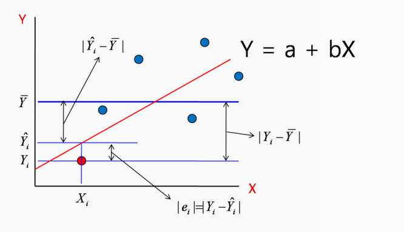

### 분산 분석 및 모델 간의 비교

선형 회귀에서 분산 분석은 모델을 평가하거나 모델 간의 비교를 위해 anova() 함수를 사용.

```r
anova(m)
```

```
## Analysis of Variance Table
##
## Response: dist
##           Df Sum Sq Mean Sq F value   Pr(>F)
## speed      1  21186 21185.5  89.567 1.49e-12 ***
## Residuals 48  11354   236.5
## ---
## Signif. codes:  0 '***' 0.001 '**' 0.01 '*' 0.05 '.' 0.1 ' ' 1
```

```r
(full <- lm(dist ~ speed, data=cars))
```

```
##
## Call:
## lm(formula = dist ~ speed, data = cars)
##
## Coefficients:
## (Intercept)        speed
##     -17.579        3.932
```

```r
(reduced <- lm(dist ~ 1, data=cars))
```

```
##
## Call:
## lm(formula = dist ~ 1, data = cars)
##
## Coefficients:
## (Intercept)
##       42.98
```

```r
anova(reduced, full)
```

```
## Analysis of Variance Table
##
## Model 1: dist ~ 1
## Model 2: dist ~ speed
##   Res.Df   RSS Df Sum of Sq      F   Pr(>F)
## 1     49 32539
## 2     48 11354  1     21186 89.567 1.49e-12 ***
## ---
## Signif. codes:  0 '***' 0.001 '**' 0.01 '*' 0.05 '.' 0.1 ' ' 1
```

### 모델 진단 그래프

일반 함수인 plot(m) 명령(plot.lm() 호출)으로 선형 회귀 모델을 평가하는데 다양한 차트를 볼 수 있다.

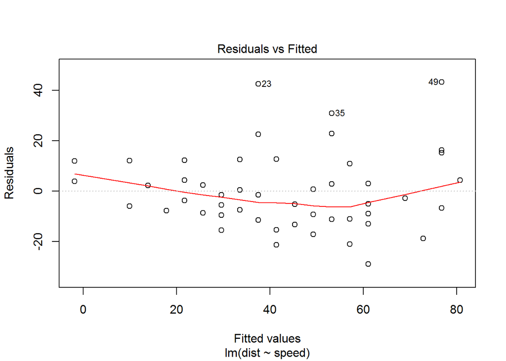

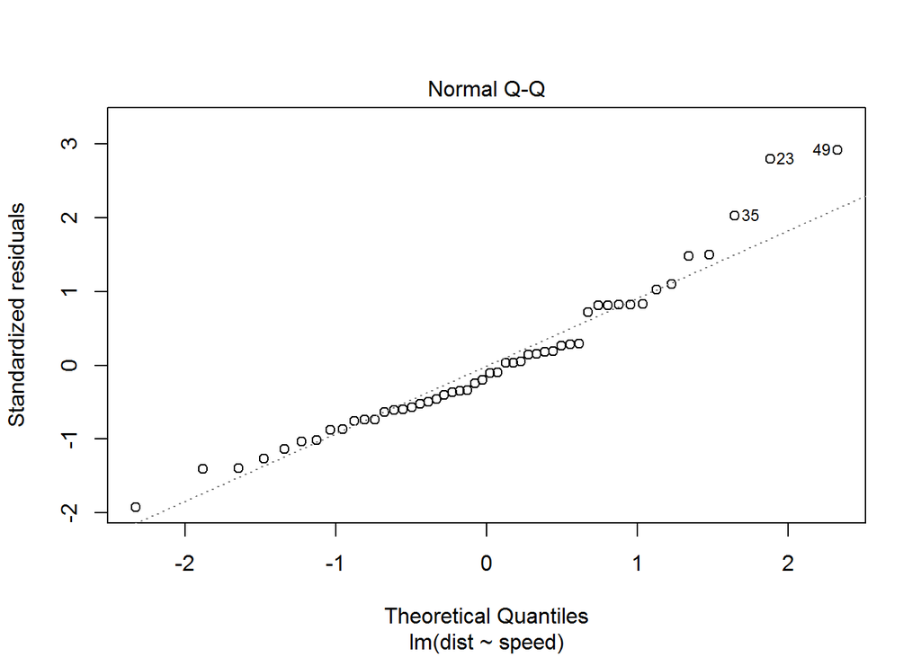

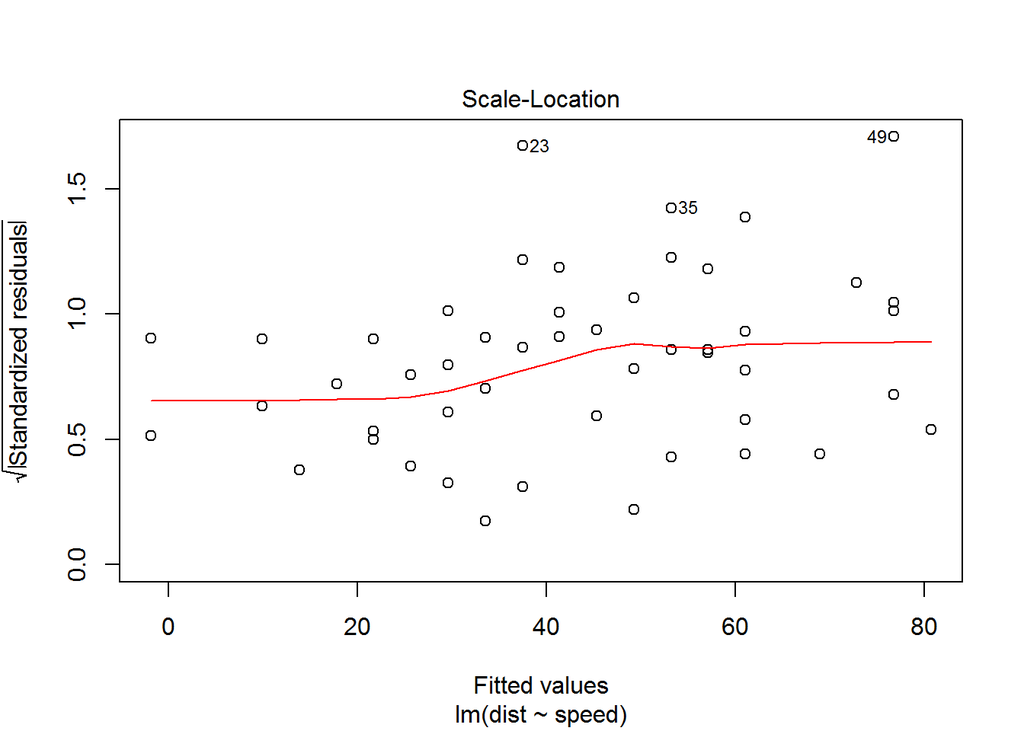

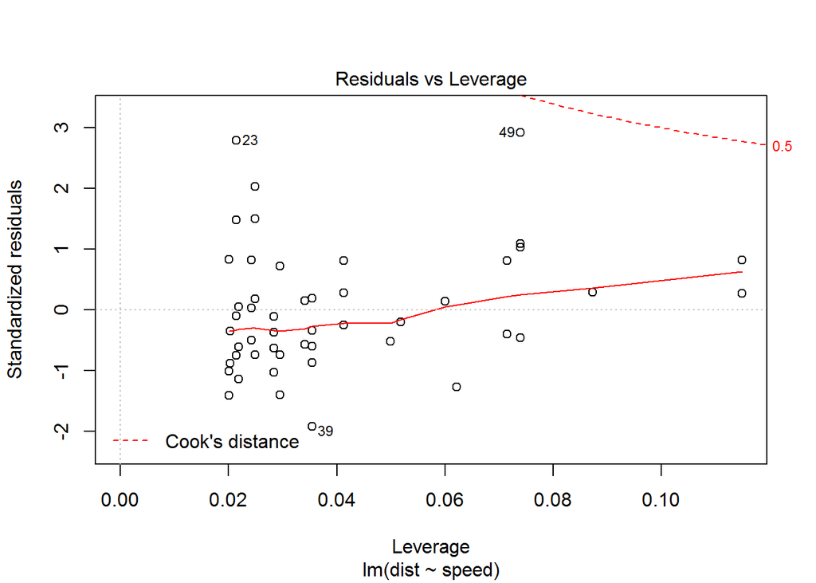

```r
plot(m)
```

의문점 * 네 번째 차트에서 leverage의 의미? * cook distance?

첫 번째 그래프는 관측값의 순서별 쿡의 거리, 두 번째 차트는 레버리지와 쿡의 거리를 보여준다.

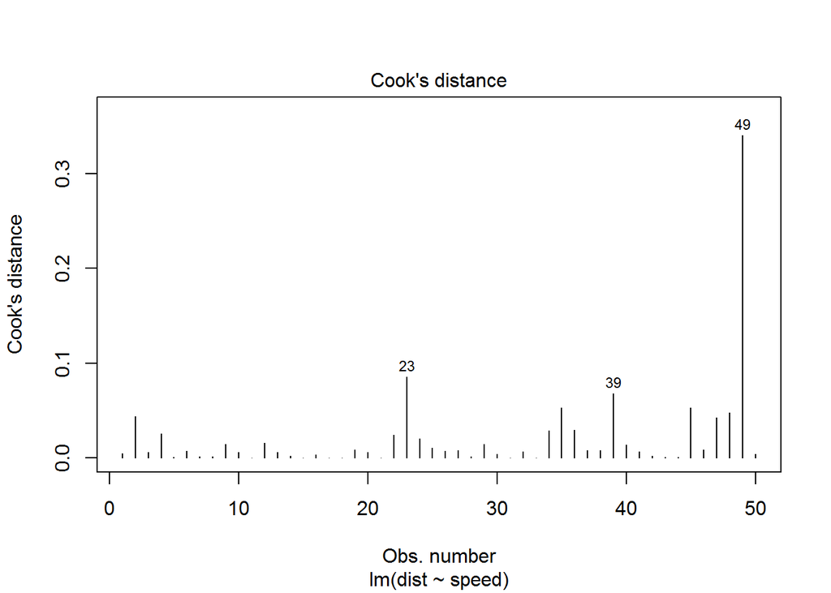

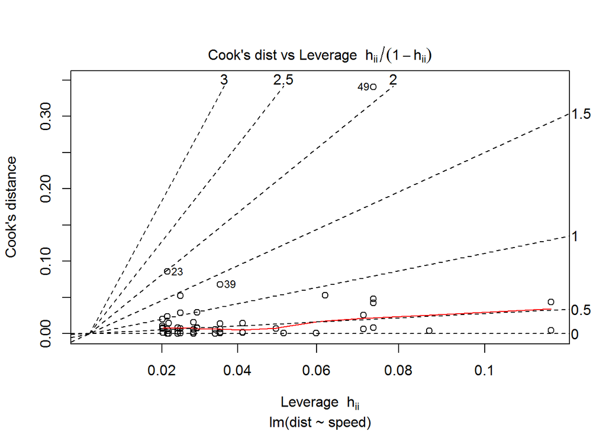

```r
plot(m, which=c(4, 6))
```

### 회귀 직선의 시각화

데이터의 산점도와 회귀 직선은 plot()을 사용해 그릴 수 있다. coef()는 선형 회귀 모델의 절편과 기울기를 추출하는 함수며, abline()은 주어진 절편과 기울기로 그래프를 그리는 함수다.

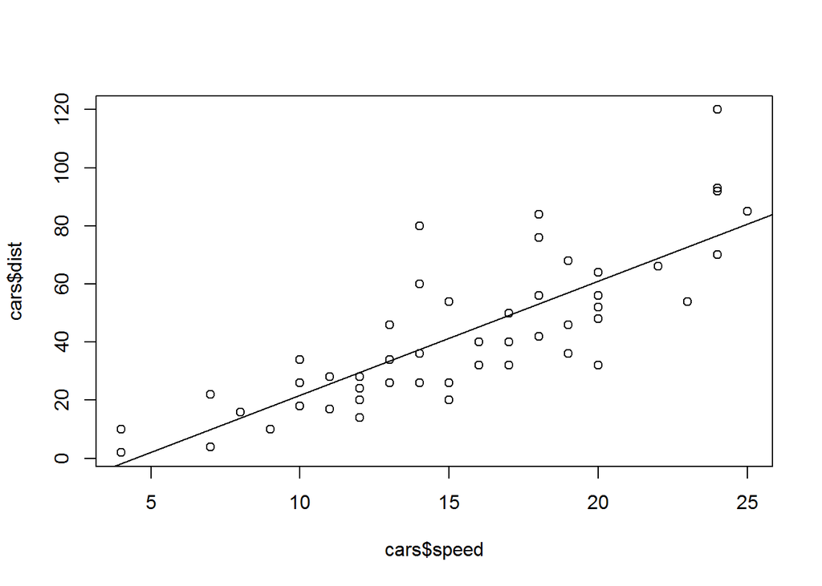

```r
plot(cars$speed, cars$dist)
abline(coef(m))
```

다음은 그래프에 추정값의 신뢰 구간을 표현하는 방법이다.

```r
summary(cars$speed)
```

```
##    Min. 1st Qu.  Median    Mean 3rd Qu.    Max.
##     4.0    12.0    15.0    15.4    19.0    25.0
```

```r
predict(m, newdata=data.frame(speed=seq(4.0, 25.0, .2)),
        interval="confidence")
```

```
##            fit         lwr       upr
## 1   -1.8494599 -12.3295433  8.630624
## 2   -1.0629781 -11.3914503  9.265494
## 3   -0.2764964 -10.4538419  9.900849
## 4    0.5099854  -9.5167401 10.536711
## 5    1.2964672  -8.5801681 11.173102
## 6    2.0829489  -7.6441504 11.810048
## 7    2.8694307  -6.7087129 12.447574
## 8    3.6559124  -5.7738833 13.085708
## 9    4.4423942  -4.8396905 13.724479
## 10   5.2288759  -3.9061655 14.363917
## 11   6.0153577  -2.9733411 15.004056
## 12   6.8018394  -2.0412521 15.644931
## 13   7.5883212  -1.1099353 16.286578
## 14   8.3748029  -0.1794301 16.929036
```

[output cut: 92 more lines]

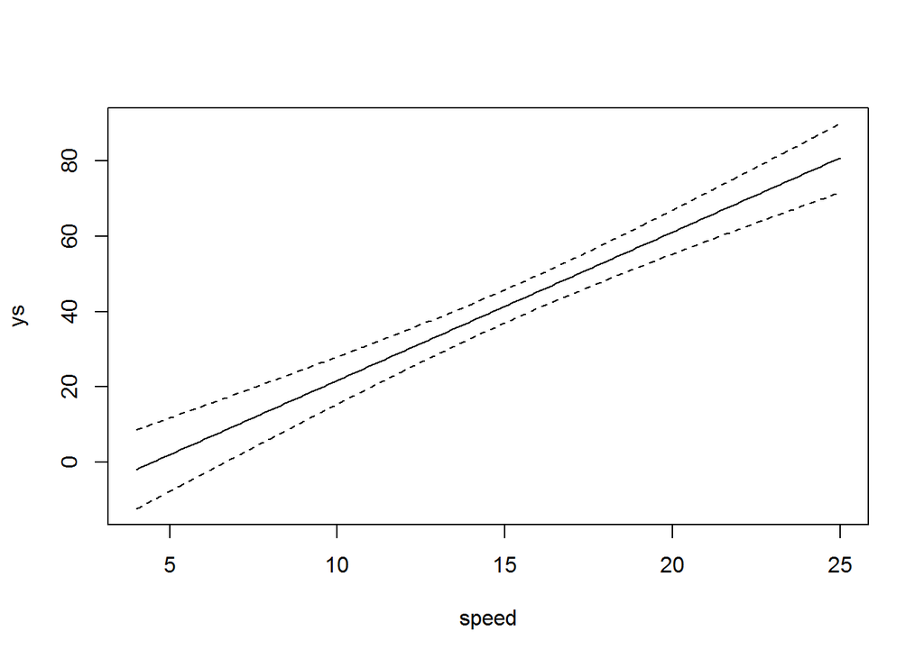

```r
speed <- seq(min(cars$speed), max(cars$speed), .1)
ys <- predict(m, newdata=data.frame(speed=speed), interval="confidence")
matplot(speed, ys, type='n')
matlines(speed, ys, lty=c(1, 2, 2), col=1)
```

## 3. 중선형 회귀

하나 이상의 독립 변수가 사용된 선형 회귀.

#### 모델 생성 및 평가

```r
(m <- lm(Sepal.Length ~ Sepal.Width + Petal.Length + Petal.Width, data=iris))
```

```
##
## Call:
## lm(formula = Sepal.Length ~ Sepal.Width + Petal.Length + Petal.Width,
##     data = iris)
##
## Coefficients:
##  (Intercept)   Sepal.Width  Petal.Length   Petal.Width
##       1.8560        0.6508        0.7091       -0.5565
```

```r
summary(m)
```

```
##
## Call:
## lm(formula = Sepal.Length ~ Sepal.Width + Petal.Length + Petal.Width,
##     data = iris)
##
## Residuals:
##      Min       1Q   Median       3Q      Max
## -0.82816 -0.21989  0.01875  0.19709  0.84570
##
## Coefficients:
##              Estimate Std. Error t value Pr(>|t|)
## (Intercept)   1.85600    0.25078   7.401 9.85e-12 ***
## Sepal.Width   0.65084    0.06665   9.765  < 2e-16 ***
## Petal.Length  0.70913    0.05672  12.502  < 2e-16 ***
## Petal.Width  -0.55648    0.12755  -4.363 2.41e-05 ***
## ---
## Signif. codes:  0 '***' 0.001 '**' 0.01 '*' 0.05 '.' 0.1 ' ' 1
##
## Residual standard error: 0.3145 on 146 degrees of freedom
## Multiple R-squared:  0.8586, Adjusted R-squared:  0.8557
## F-statistic: 295.5 on 3 and 146 DF,  p-value: < 2.2e-16
```

위의 결과에서 독립변수의 p값이 모두 0.05보다 작아 모두 중요한 변수이다. 중선형 회귀에서 귀무가설은 ’모든 계수가 0이다’이다. 따라서 F 통계량에서 p-value < 0.05이기 때문에 하나 이상의 독립 변수의 계수가 0이 아니다.

#### 범주형 변수

다음은 범주형 변수인 Species를 포함한 중선형 회귀다.

```r
(m <- lm(Sepal.Length ~ ., data=iris))
```

```
##
## Call:
## lm(formula = Sepal.Length ~ ., data = iris)
##
## Coefficients:
##       (Intercept)        Sepal.Width       Petal.Length
##            2.1713             0.4959             0.8292
##       Petal.Width  Speciesversicolor   Speciesvirginica
##           -0.3152            -0.7236            -1.0235
```

```r
summary(m)
```

```
##
## Call:
## lm(formula = Sepal.Length ~ ., data = iris)
##
## Residuals:
##      Min       1Q   Median       3Q      Max
## -0.79424 -0.21874  0.00899  0.20255  0.73103
##
## Coefficients:
##                   Estimate Std. Error t value Pr(>|t|)
## (Intercept)        2.17127    0.27979   7.760 1.43e-12 ***
## Sepal.Width        0.49589    0.08607   5.761 4.87e-08 ***
## Petal.Length       0.82924    0.06853  12.101  < 2e-16 ***
## Petal.Width       -0.31516    0.15120  -2.084  0.03889 *
## Speciesversicolor -0.72356    0.24017  -3.013  0.00306 **
## Speciesvirginica  -1.02350    0.33373  -3.067  0.00258 **
## ---
## Signif. codes:  0 '***' 0.001 '**' 0.01 '*' 0.05 '.' 0.1 ' ' 1
##
## Residual standard error: 0.3068 on 144 degrees of freedom
## Multiple R-squared:  0.8673, Adjusted R-squared:  0.8627
## F-statistic: 188.3 on 5 and 144 DF,  p-value: < 2.2e-16
```

위의 결과에서 setosa가 없는 이유는 범주형 변수를 가변수를 사용해 표현했기 때문이다.

| 표현하고자 하는 Species | Speciesversicolor | Speciesvirginica |
| --- | --- | --- |
| setosa | 0 | 0 |
| versicolor | 1 | 0 |
| virginica | 0 | 1 |

```r
model.matrix(m)[c(1,51,101),]
```

```
##     (Intercept) Sepal.Width Petal.Length Petal.Width Speciesversicolor
## 1             1         3.5          1.4         0.2                 0
## 51            1         3.2          4.7         1.4                 1
## 101           1         3.3          6.0         2.5                 0
##     Speciesvirginica
## 1                  0
## 51                 0
## 101                1
```

#### 중선형 회귀 모델의 시각화

```r
with(iris, plot(Sepal.Width, Sepal.Length, cex=.7, pch=as.numeric(Species)))
m <- lm(Sepal.Length ~ Sepal.Width + Species, data=iris)
coef(m)
```

```
##       (Intercept)       Sepal.Width Speciesversicolor  Speciesvirginica
##         2.2513932         0.8035609         1.4587431         1.9468166
```

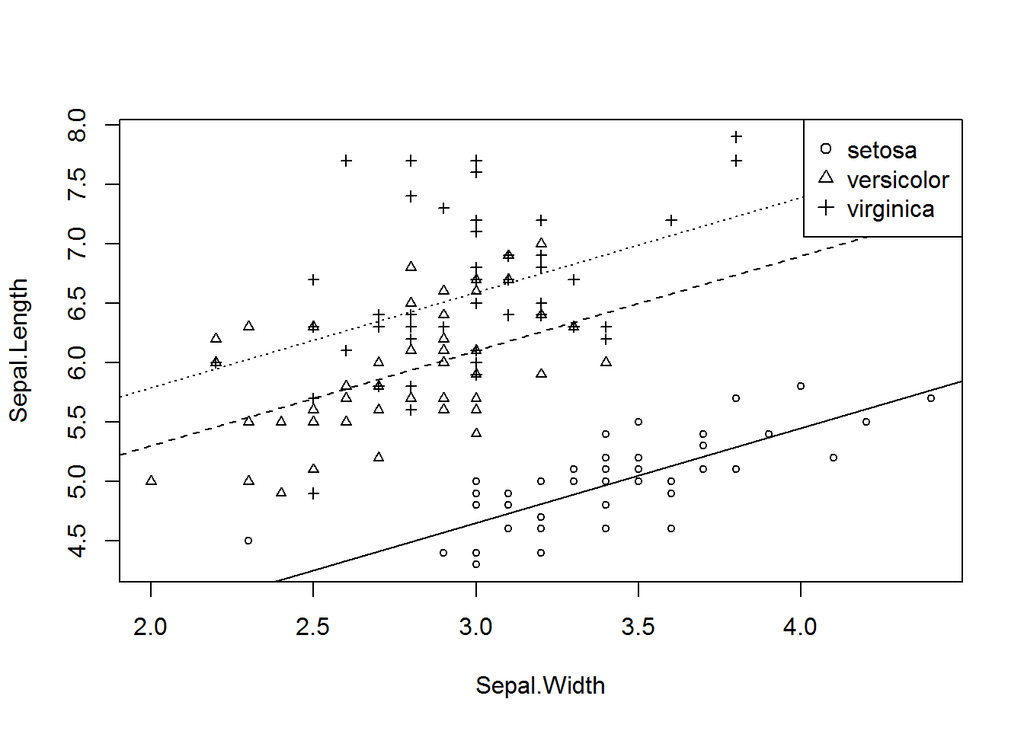

```r
abline(2.25, 0.80, lty=1)
abline(2.25 + 1.45, 0.80, lty=2)
abline(2.25 + 1.94, 0.80, lty=3)
legend("topright", levels(iris$Species), pch=1:3, bg="white")
```

#### 표현식을 위한 l()의 사용

2차 이상이나 두 변수의 합을 하나의 변수로 보고 회귀 분석할때 I()안에 원하는 수식을 표현한다. I()는 객체의 해석과 변환을 방지한다.

```r
x <- 1:1000
y <- x^2 + 3*x + 5 + rnorm(1000)
lm(y ~ I(x^2) + x)
```

```
##
## Call:
## lm(formula = y ~ I(x^2) + x)
##
## Coefficients:
## (Intercept)       I(x^2)            x
##       5.043        1.000        3.000
```

#### 변수의 변환

```r
x <- 101:200
y <- exp(3 * x + rnorm(100))
lm(log(y) ~ x)
```

```
##
## Call:
## lm(formula = log(y) ~ x)
##
## Coefficients:
## (Intercept)            x
##     -0.1592       3.0004
```

#### 상호작용

상호 작용은 독립 변수 간의 상호 작용이 종속 변수에 영향을 주는 경우를 말한다. 이 영향을 주는 방법은 합이 아니라 곱의 형태일때를 말한다.

```r
data(Orange)
Orange
```

```
##    Tree  age circumference
## 1     1  118            30
## 2     1  484            58
## 3     1  664            87
## 4     1 1004           115
## 5     1 1231           120
## 6     1 1372           142
## 7     1 1582           145
## 8     2  118            33
## 9     2  484            69
## 10    2  664           111
## 11    2 1004           156
## 12    2 1231           172
## 13    2 1372           203
## 14    2 1582           203
```

[output cut: 21 more lines]

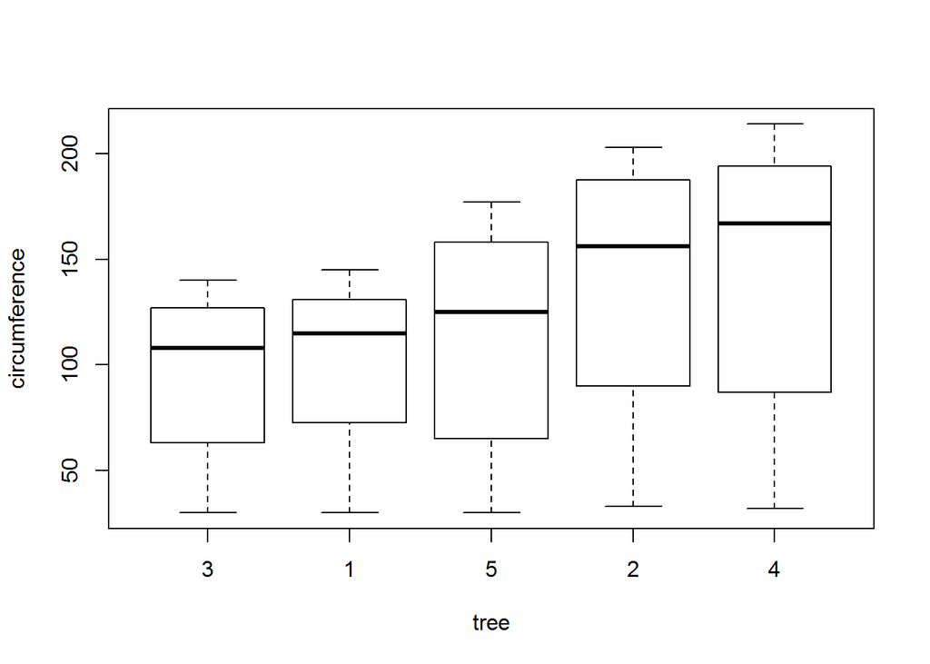

```r
with(Orange, plot(Tree, circumference, xlab="tree", ylab="circumference"))
```

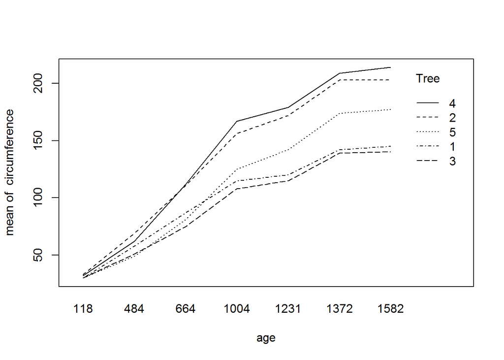

```r
# 상호 작용 그래프
with(Orange, interaction.plot(age, Tree, circumference))
```

```r
# Tree 열의 데이터를 순서 없는 명목형 변수로 변환
Orange[,"fTree"] <- factor(Orange[, "Tree"], ordered=FALSE)
# fTree, age, fTree:age를 설명 변수로 선형 회귀를 수행
m <- lm(circumference ~ fTree * age, data=Orange)
anova(m)
```

```
## Analysis of Variance Table
##
## Response: circumference
##           Df Sum Sq Mean Sq  F value    Pr(>F)
## fTree      4  11841    2960  27.2983 8.428e-09 ***
## age        1  93772   93772 864.7348 < 2.2e-16 ***
## fTree:age  4   4043    1011   9.3206 9.402e-05 ***
## Residuals 25   2711     108
## ---
## Signif. codes:  0 '***' 0.001 '**' 0.01 '*' 0.05 '.' 0.1 ' ' 1
```

```r
head(model.matrix(m))
```

```
##   (Intercept) fTree1 fTree5 fTree2 fTree4  age fTree1:age fTree5:age
## 1           1      1      0      0      0  118        118          0
## 2           1      1      0      0      0  484        484          0
## 3           1      1      0      0      0  664        664          0
## 4           1      1      0      0      0 1004       1004          0
## 5           1      1      0      0      0 1231       1231          0
## 6           1      1      0      0      0 1372       1372          0
##   fTree2:age fTree4:age
## 1          0          0
## 2          0          0
## 3          0          0
## 4          0          0
## 5          0          0
## 6          0          0
```

```r
mm <- model.matrix(m)
# age가 포함된 열만 추출
mm[, grep("age", colnames(mm))]
```

```
##     age fTree1:age fTree5:age fTree2:age fTree4:age
## 1   118        118          0          0          0
## 2   484        484          0          0          0
## 3   664        664          0          0          0
## 4  1004       1004          0          0          0
## 5  1231       1231          0          0          0
## 6  1372       1372          0          0          0
## 7  1582       1582          0          0          0
## 8   118          0          0        118          0
## 9   484          0          0        484          0
## 10  664          0          0        664          0
## 11 1004          0          0       1004          0
## 12 1231          0          0       1231          0
## 13 1372          0          0       1372          0
## 14 1582          0          0       1582          0
```

[output cut: 21 more lines]